# Data Analysis for loan Data Prosper

## Abstract

[Prosper](https://www.prosper.com/about) was founded in 2005 as the first peer-to-peer lending marketplace in the United States. Since then, Prosper has facilitated more than $14 billion in loans to more than 880,000 people.

As Master Accountant worked in bank for more than 11 years, I get interested in this dataset to study Data Analysis by working in real dataset containing loan information.

Second, explored the users who are interested about loan data, and found three main stakeholders: lenders, borrowers, and the organization itself. In this analysis I decided to focus on the organization (Prosper) as stakeholder, and designed my exploration for their interests.

Finally, my exploration divided to 3 segments analytical to increasing complexity order: Univariate Plots, Bivariate Plots, and Multivariate Plots, Then I inserted Reflection segment in the end to summarize my experience during the EDA.

### Exploring and Cleaning Variables

In this analysis we want to answer the following questions: Univariate analysis - What are the characteristics of the loan (loan amount, term, etc.)? - Who uses Prosper and where? - Why people use Prosper?

# Load the Data

[output not shown]

[output cut: 193 more lines]

[output not shown]

[output not shown]

[output cut: 67 more lines]

# Why people use Prosper?

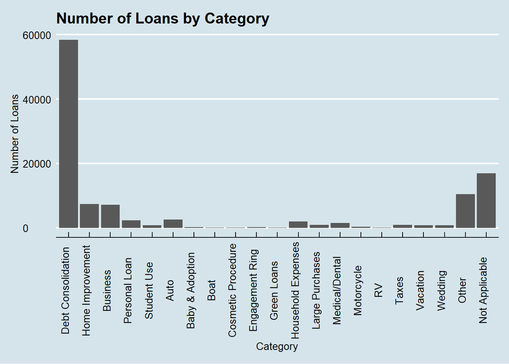

Majority loans are debt consolidations, with small but significant amounts of home improvement and business loans.It is really strange that people took loans to reimburse loans/debts and lenders also issued loans to these people.

### How much do people borrow?

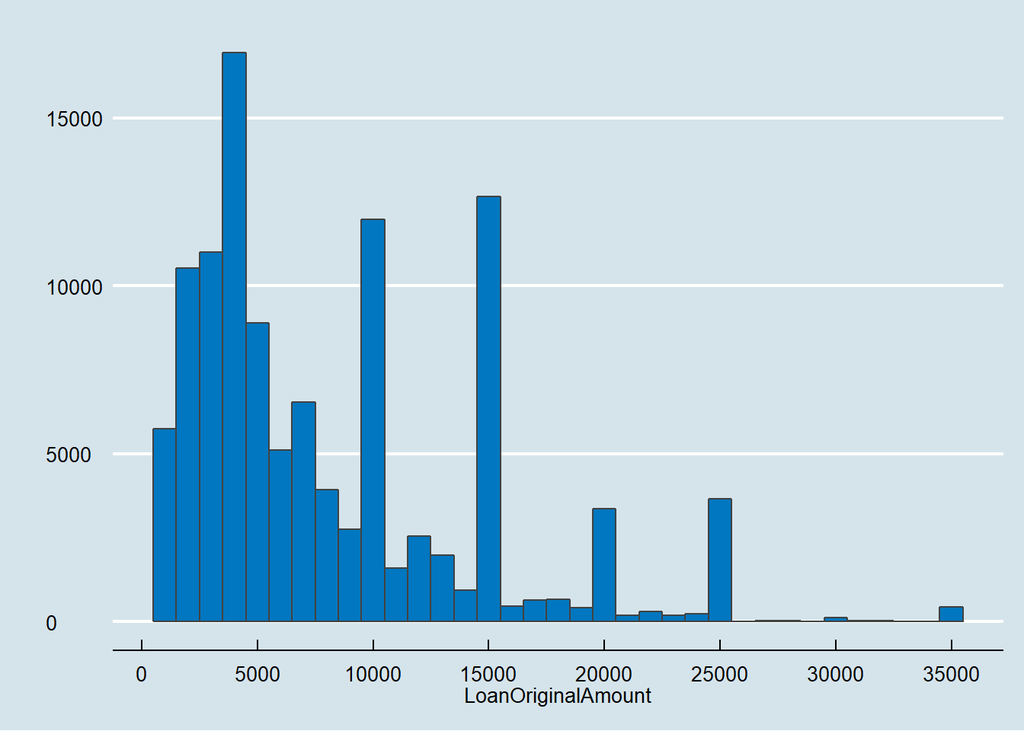

Most loans lies below $15,000, which indicates that most of the borrowers using Prosper are looking for small(er) loans and spikes in the count on round values like $10,000, $15,000, and even $20,000 and $25,000.

```
##    Min. 1st Qu.  Median    Mean 3rd Qu.    Max.
##    1000    4000    6500    8337   12000   35000
```

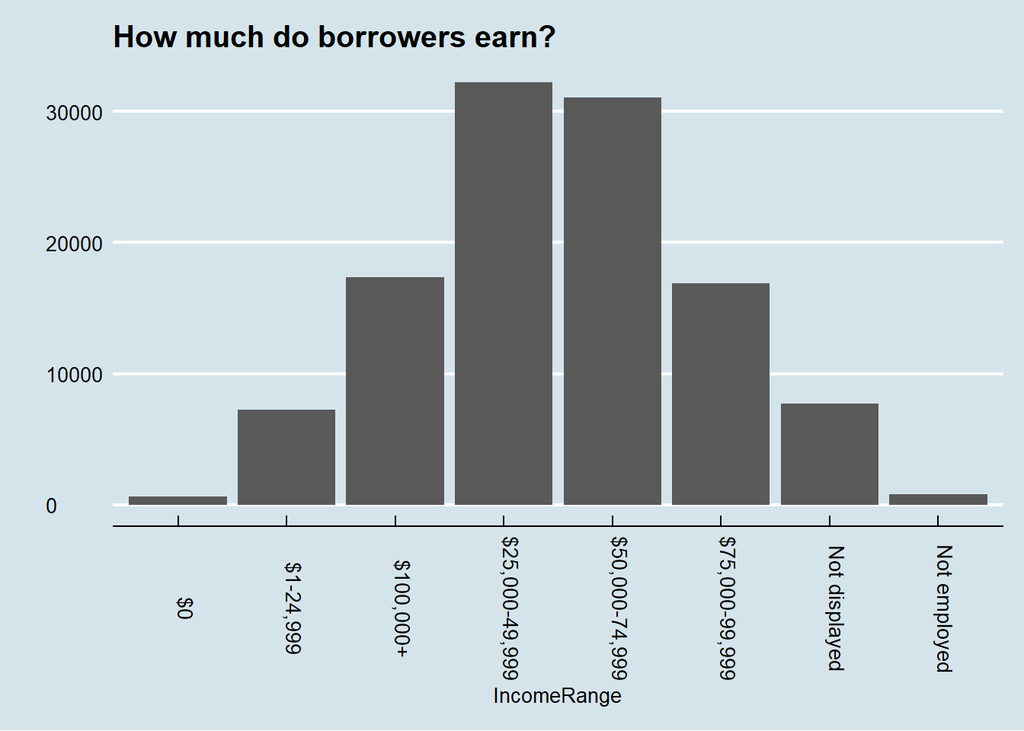

Most of borrowers Income ranges from $25,000 - $74,999. Question: Why does there is borrowers with “Zero”" income? Maybe exploring more information about those borrowers would make it clearer that why they can get the loan.

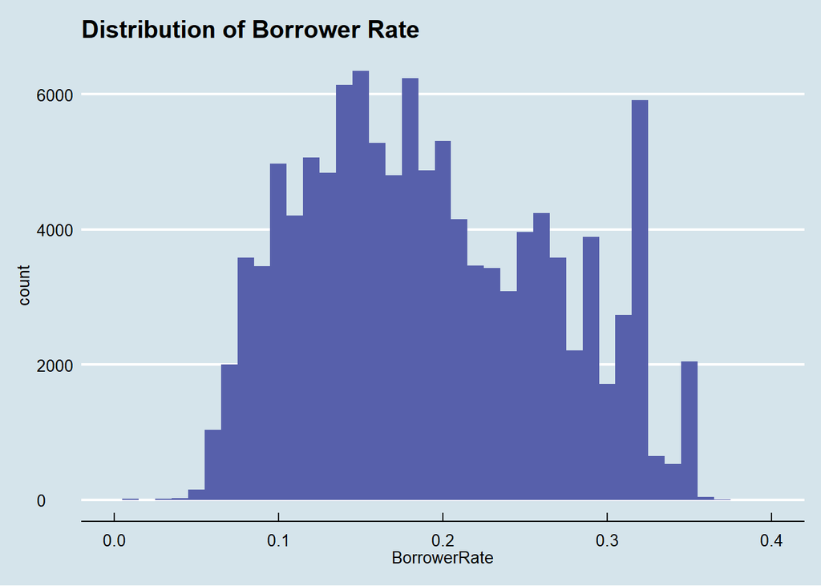

```
##    Min. 1st Qu.  Median    Mean 3rd Qu.    Max.
##  0.0000  0.1340  0.1840  0.1928  0.2500  0.4975
```

The Borrower Rate seems quite uniformly distributed with peak around 0.16. Most people borrow between 10%-20% while mean being at 19.28%.There’s spike occurs, around 0.3.

```
## [1] "2005-11-09" "2014-03-10"
```

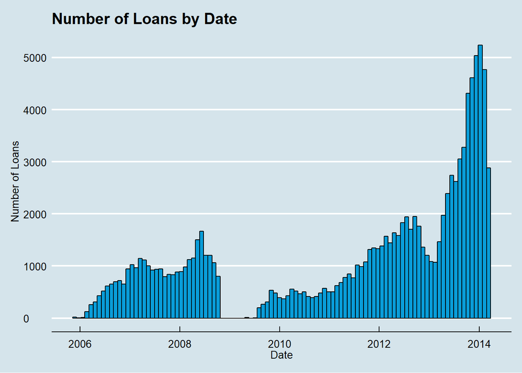

There was a dip in loans offered in 2009 corresponding to their [Prosper SEC relaunch](https://en.wikipedia.org/wiki/Prosper_Marketplace#2009_post_SEC_relaunch), but there’s been a growth of loan offerings ever since. The dip in 2014 reflects the fact that the data was collected up until 03/11/2014

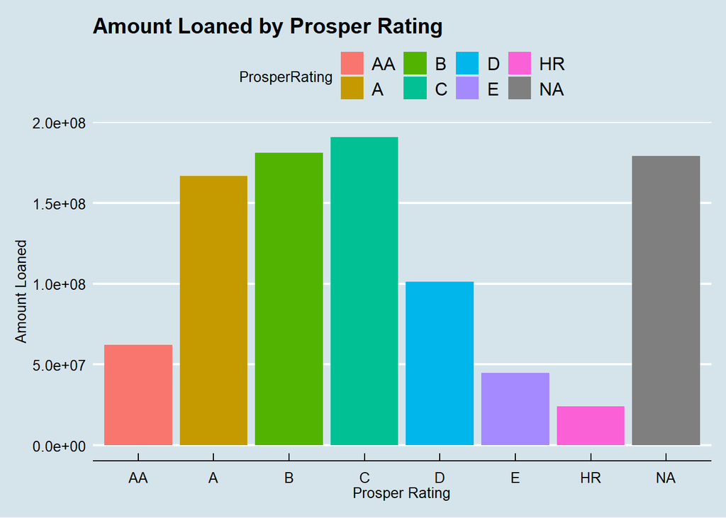

The plot looked approximately normally distrubuted, except for “NA” Not Applicable.‘C’ is the most frequent rating in our data and the highest (AA) and the lowest (HR) rating are less common comparing with other ratings in between.Null values because Prosper Rating only applicable for loans originated after July 2009.

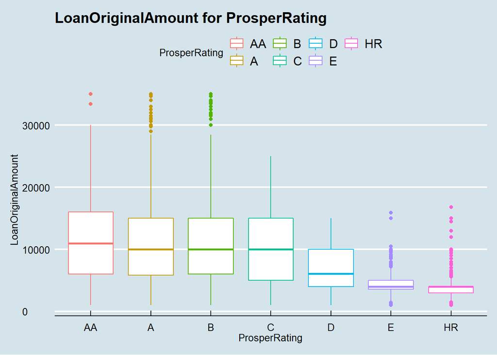

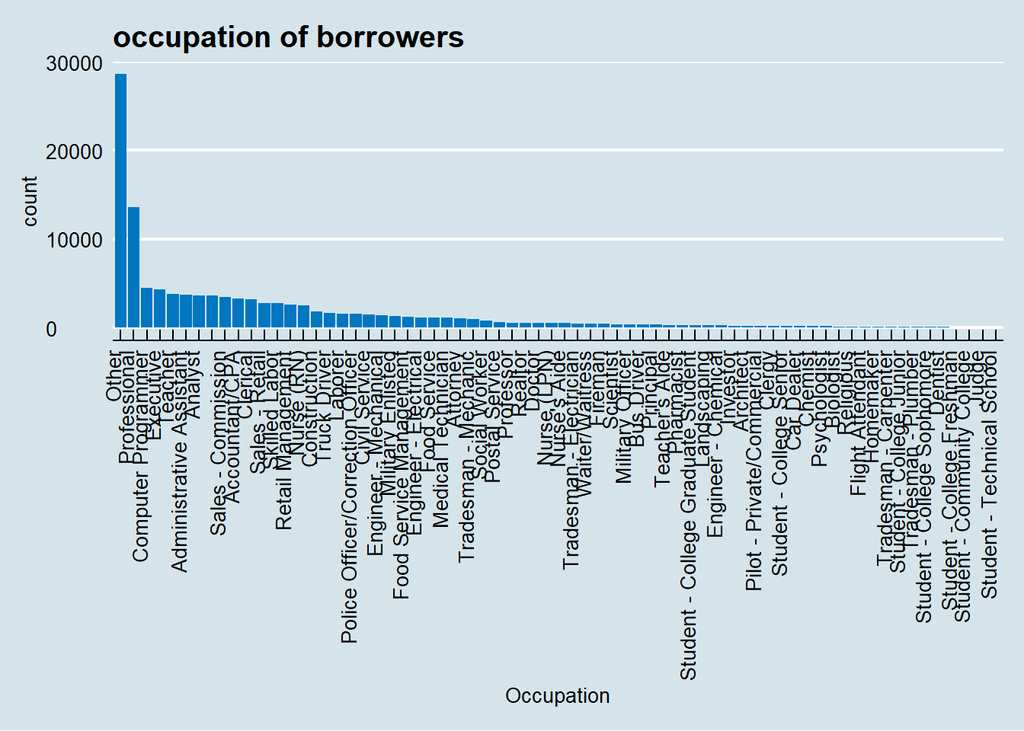

‘Other’ and ‘Professional’ are ambiguous options for occupations and they are away from the rest of the occupations include analysts, accountants, computer programmers, teachers and executives.

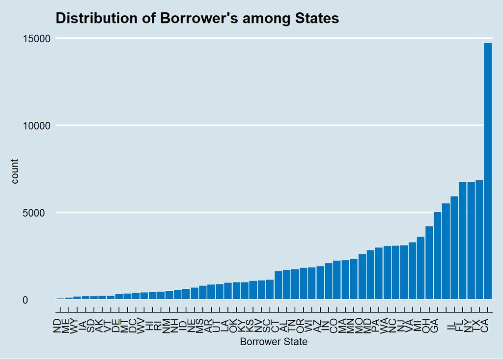

California is by far the biggest, and that was expected because it is the state where Prosper was founded followed by other popular states include Florida, New York, Texas and Illinois.

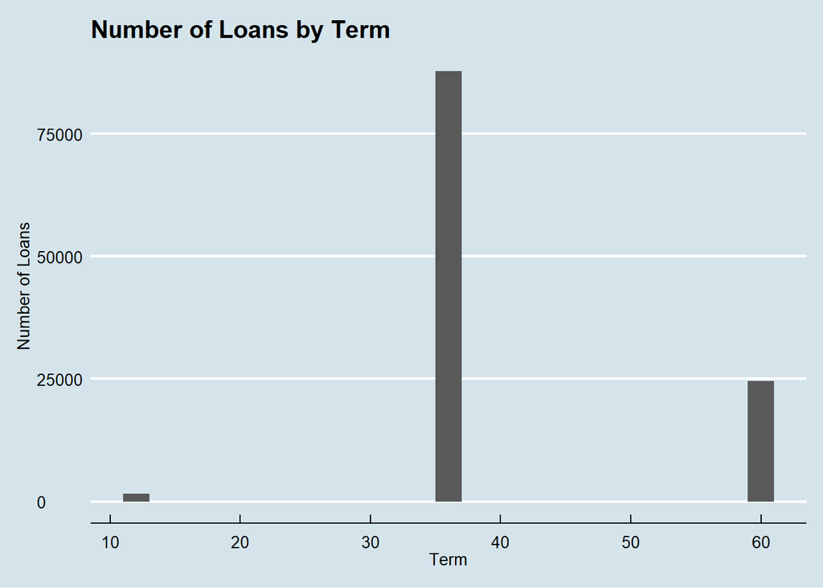

```
##    Min. 1st Qu.  Median    Mean 3rd Qu.    Max.
##   12.00   36.00   36.00   40.83   36.00   60.00
```

Most loan-terms are 36-month, with some 60-month, and a negligible amount of 12-month terms.Interestingly there are no records with 24 and 48 months tenure.

# Univariate Analysis

### What is the structure of your dataset?

There are 113937 loans in this dataset and 81 dataset (I only use 11 among them)

Other observations:

- Most loans are taken for debt consolidation. Individuals in all income categories take loans for debt consolidation and the amount varies largely
- Individuals earning between $25k and $50k constitute the largest group of borrowers. Those with over $100k income borrow more
- Most of loans term was 36 months and there was not even single loan in 24 and 48 months tenure.

### What is/are the main feature(s) of interest in your dataset?

The main features of the dataset is the Prosper rating.

### What other features in the dataset do you think will help support your investigation into your feature(s) of interest?

Loans’ Category, loan amount, borrower rate (or interest rate),borrower income, borrower employment status.

### Did you create any new variables from existing variables in the dataset?

I adjust “ProsperRating” based on ProsperRating..Alpha. Formatting dates “ListingCreationDate” and “LoanOriginationDate” instead of using them as factor.

Convert ListingCategory from numeric to factor variable using the keys given in the Google Spreadsheet

### Of the features you investigated, were there any unusual distributions? Did you perform any operations on the data to tidy, adjust, or change the form of the data? If so, why did you do this?

Most of the distributions are positively skewed and there’s also peopole who makes 0 dolars monthly salary. Interestingly there are no Term with 24 and 48 months tenure. The biggest reason people take loan is to pay them back. Second and Third largest category are not even categories in themselves i.e. Not Available and Other.

I formatted two variable (i.e. ProsperRating and ListingCategory) names to be more concise and meaningful. Created factor levels for ListingCategory variables for better understanding and data manipulation.

# Bivariate Plots Section

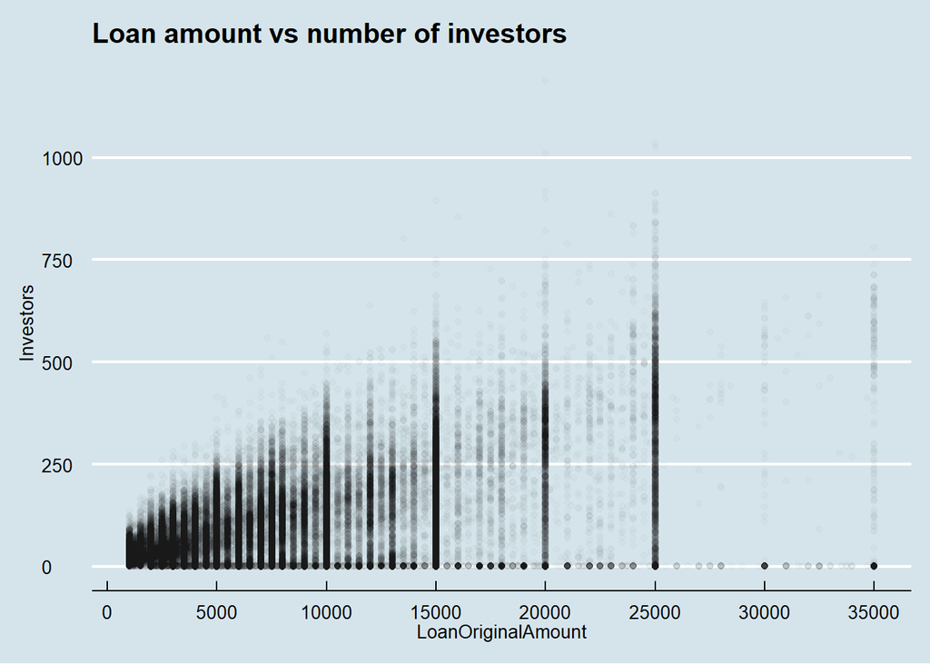

The number of investors per loan seem to be heavily positive skewed.Spikes on Loan amount 5000,1000,2000 and 2500 indicates most borrowers want fixed and relatively small loans.

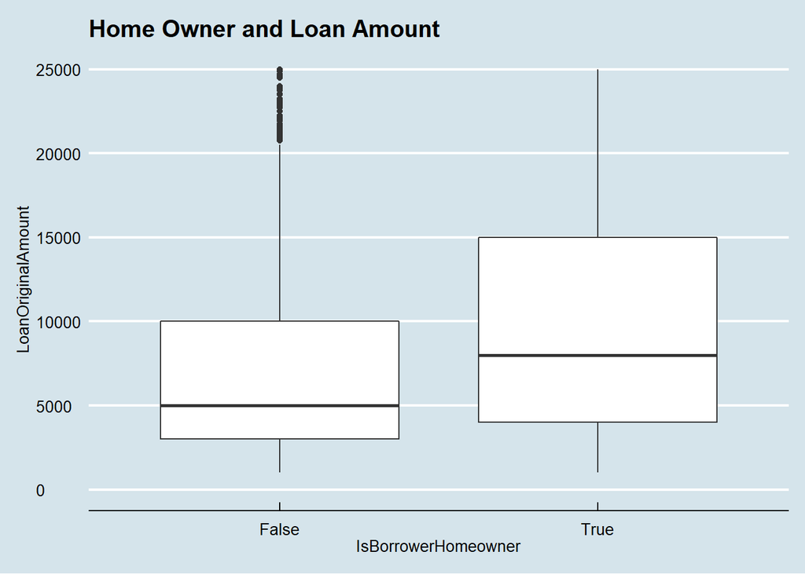

Borrower who home owner had receive bigger loan than other one who not own the home.

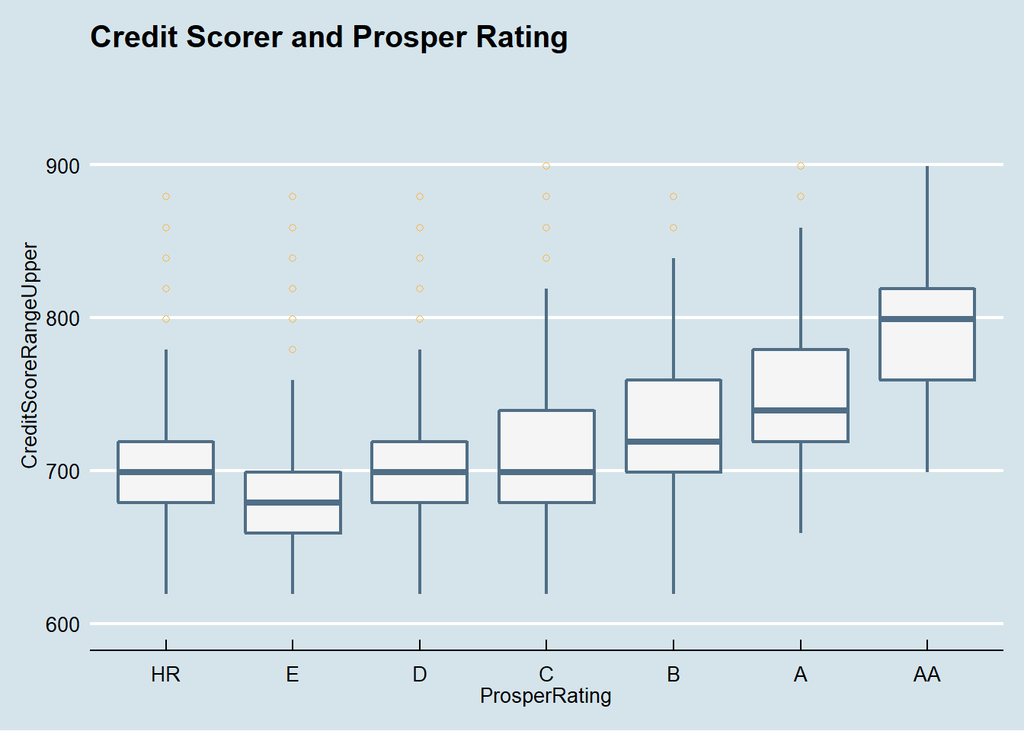

High Credit Score Upper is assign to excellent rating (AA), and surprise is Poor prosper rating “HR” have high credit score that rating E.

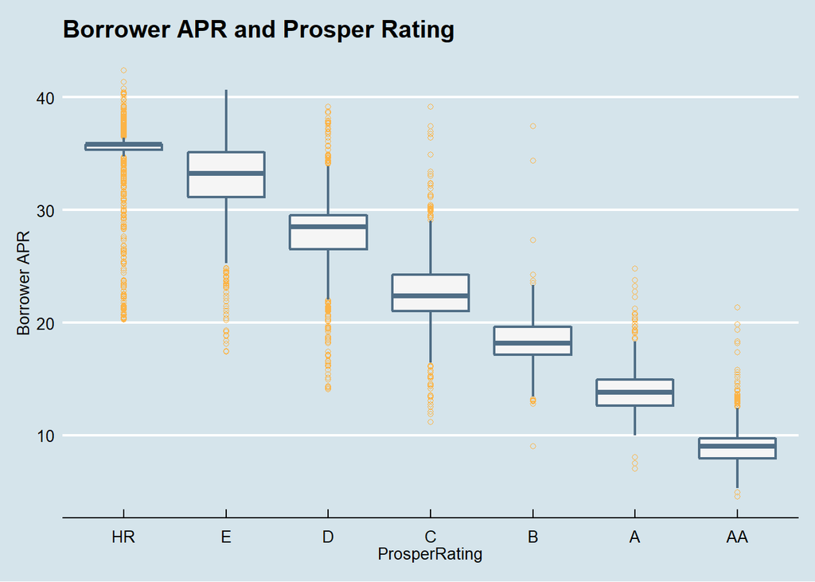

### Talk about some of the relationships you observed in this part of the investigation. How did the feature(s) of interest vary with other features in the dataset?

For the borrower, BorrowerRate depend on ProsperRating, IsBorrowerHomeowner and Loan Amount,

### Did you observe any interesting relationships between the other features (not the main feature(s) of interest)?

I also observe when the borrower who are home owner receive bigger loan than other one who not own the home.

### What was the strongest relationship you found?

I found the strongest relationshipbetween ProsperRating and BorrowerAPR.

# Multivariate Plots Section

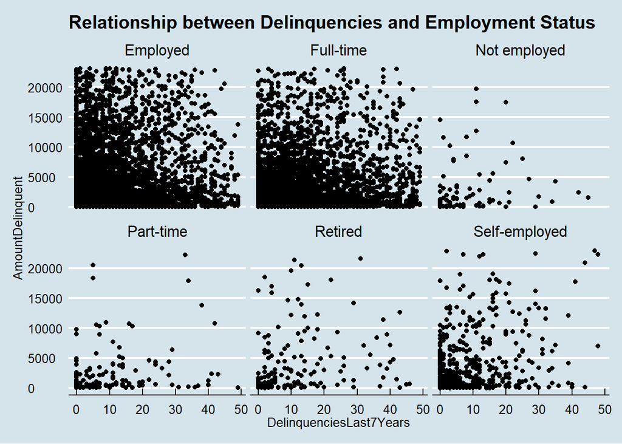

I wanted to see the relationship between the amount borrowers were delinquent and the number of delinquencies they’ve had over the last 7 years then separated that by employment status to see if people that weren’t full employed had higher delinquencies or owed more money.Overplotting and general dispersion of data doesn’t really reveal the trend

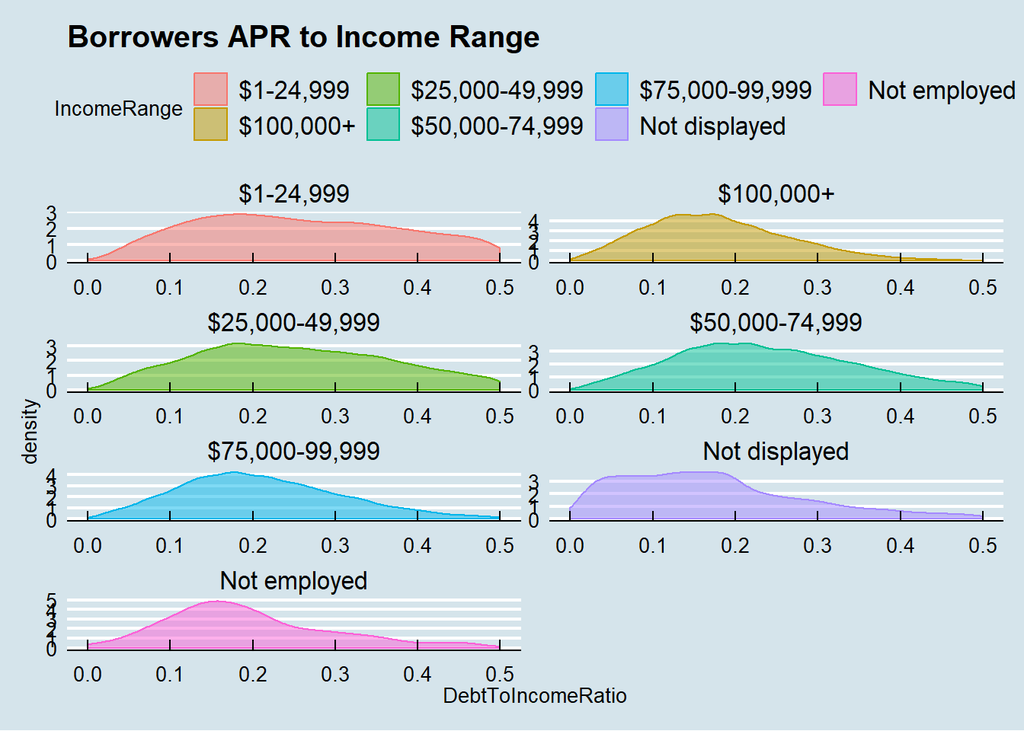

```
##  99%
## 0.86
```

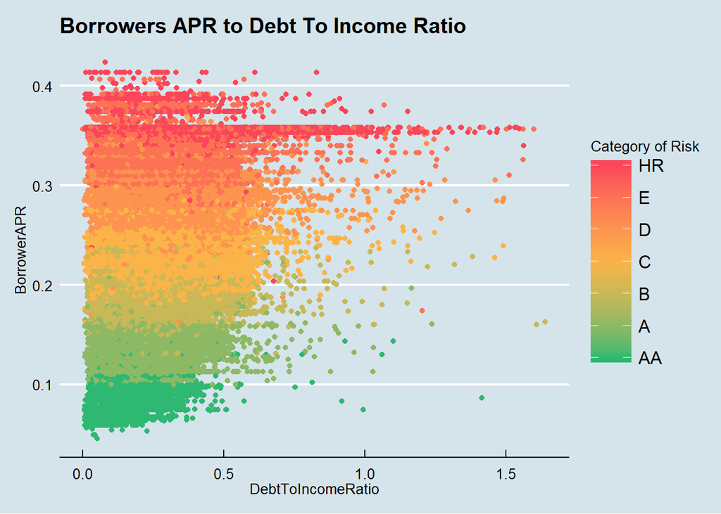

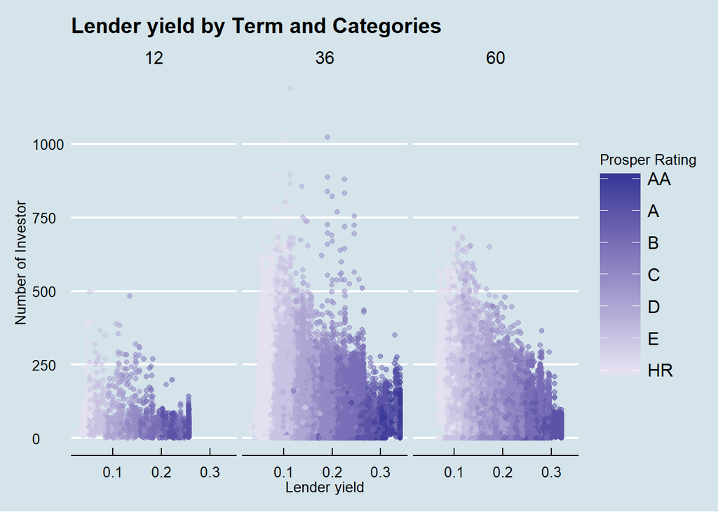

# Multivariate Analysis

### Were there any interesting or surprising interactions between features?

High amount of loans should generate high risk, since it’s risky if someone doesn’t pay the the loans. But here the rating doesn’t event consider the loan amount. Even the opposite, low loan amount could generate higher risk.

### OPTIONAL: Did you create any models with your dataset? Discuss the strengths and limitations of your model.

> No,I did not.

# Final Plots and Summary

### Plot One

[figure not shown]

### Plot Two

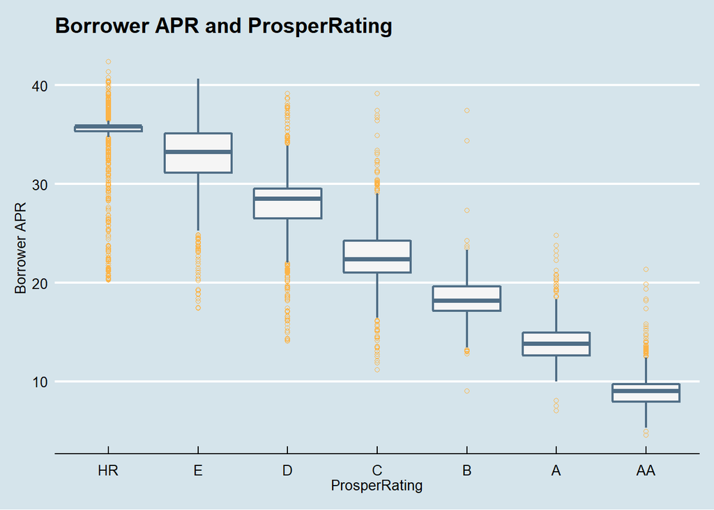

### Description Two

The boxplots above show the relationship between borrower’s Prosper rating and their assigned Annual Percentage Rate (APR).It’s very clear that as we go down the ladder of risk - from a ‘High Risk’ to an ‘AA’ rating - the APR for the borrower reduces drastically.The variation in APRs also decreases as the loans get less riskier as displayed by the decreasing size of the boxes in the boxplots when going from ‘E’ to ‘AA’. There is also a reduction in the number of outliers. This indeed proves that the lenders like to charge less from borrowers with better prosper score.

### Plot Three

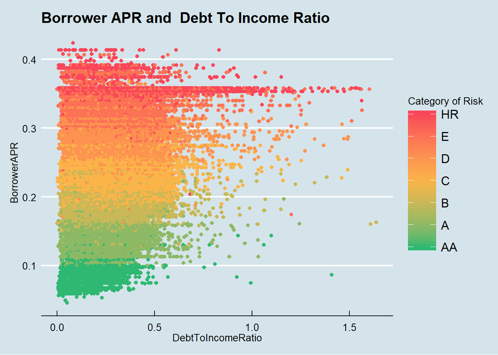

# Reflection

The Prosper Loan data set contains information on 113937 loan records.We have been able to analyze that Prosper’s portfolio has really changed between 2005 and 2014.I started by going through the Prosper website to understand the concept and details of some of the fields in the data set. Then I started understanding the individual variables in the data set, and then I explored interesting questions and leads as I continued to make observations on plots.

Following are some of the interesting features which I observed during the exploratory analysis: